Key Word(s): pandas

Download Notebook

# CS109A Introduction to Data Science

[figure not shown]

## Lab 2: EDA with Pandas (+seaborn)¶

**Harvard University**  
**Fall 2021**  
**Instructors**: Pavlos Protopapas and Natesh Pillai  
**Authors**: Natesh Pillai

```python
## RUN THIS CELL TO GET THE RIGHT FORMATTING
import requests
from IPython.core.display import HTML
styles = requests.get("https://raw.githubusercontent.com/Harvard-IACS/2018-CS109A/master/content/styles/cs109.css").text
HTML(styles)
```

```python
import pandas as pd
import seaborn as sns
import matplotlib.pyplot as plt
```

In this lecture we will look at tools for plotting using both matplotlib and seaborn.

## Load data

The file *quartets.csv* contains 4 different tiny datasets that we will use to quickly understand the value of ploting.

```python
quartets = pd.read_csv('quartets.csv', index_col=0)
```

### Exploration

```python
quartets.info()
```

```
<class 'pandas.core.frame.DataFrame'>
Int64Index: 44 entries, 1 to 11
Data columns (total 3 columns):
 #   Column   Non-Null Count  Dtype
---  ------   --------------  -----
 0   x        44 non-null     int64
 1   y        44 non-null     float64
 2   quartet  44 non-null     object
dtypes: float64(1), int64(1), object(1)
memory usage: 1.4+ KB
```

We see there are 44 entries, two numerical columns x and y and one column to potentially identify every quartet dataset.

How does this dataframe look like?

```python
quartets.head()
```

|  | x | y | quartet |
| --- | --- | --- | --- |
| 1 | 10 | 8.04 | I |
| 2 | 8 | 6.95 | I |
| 3 | 13 | 7.58 | I |
| 4 | 9 | 8.81 | I |
| 5 | 11 | 8.33 | I |

How do random samples look like?

```python
quartets.sample(5)
```

|  | x | y | quartet |
| --- | --- | --- | --- |
| 8 | 19 | 12.50 | IV |
| 3 | 13 | 7.58 | I |
| 3 | 13 | 12.74 | III |
| 5 | 11 | 8.33 | I |
| 2 | 8 | 5.76 | IV |

Quartet's names

```python
quartets['quartet'].unique().tolist()
```

```
['I', 'II', 'III', 'IV']
```

Display the first 3 samples from every dataset

```python
quartets.groupby('quartet').head(3)
```

|  | x | y | quartet |
| --- | --- | --- | --- |
| 1 | 10 | 8.04 | I |
| 2 | 8 | 6.95 | I |
| 3 | 13 | 7.58 | I |
| 1 | 10 | 9.14 | II |
| 2 | 8 | 8.14 | II |
| 3 | 13 | 8.74 | II |
| 1 | 10 | 7.46 | III |
| 2 | 8 | 6.77 | III |
| 3 | 13 | 12.74 | III |
| 1 | 8 | 6.58 | IV |
| 2 | 8 | 5.76 | IV |
| 3 | 8 | 7.71 | IV |

Display 2 random samples from every dataset

```python
quartets.groupby('quartet').sample(2)
```

|  | x | y | quartet |
| --- | --- | --- | --- |
| 5 | 11 | 8.33 | I |
| 10 | 7 | 4.82 | I |
| 3 | 13 | 8.74 | II |
| 7 | 6 | 6.13 | II |
| 10 | 7 | 6.42 | III |
| 2 | 8 | 6.77 | III |
| 10 | 8 | 7.91 | IV |
| 4 | 8 | 8.84 | IV |

Display every quartet's dataset size

```python
quartets.groupby('quartet').size()
```

```
quartet
I      11
II     11
III    11
IV     11
dtype: int64
```

## Descriptive Statistics

```python
quartets.groupby('quartet').agg(['mean', 'std']).round(3)
```

| quartet | x mean | x std | y mean | y std |
| --- | --- | --- | --- | --- |
| I | 9 | 3.317 | 7.501 | 2.032 |
| II | 9 | 3.317 | 7.501 | 2.032 |
| III | 9 | 3.317 | 7.500 | 2.030 |
| IV | 9 | 3.317 | 7.501 | 2.031 |

Almost same mean and standard deviation for every quartet.  
This looks like all quartets samples could be sampled from the same distribution.  
These are tiny datasets so we could read them all

```python
quartets[quartets['quartet'] == 'I']
```

|  | x | y | quartet |
| --- | --- | --- | --- |
| 1 | 10 | 8.04 | I |
| 2 | 8 | 6.95 | I |
| 3 | 13 | 7.58 | I |
| 4 | 9 | 8.81 | I |
| 5 | 11 | 8.33 | I |
| 6 | 14 | 9.96 | I |
| 7 | 6 | 7.24 | I |
| 8 | 4 | 4.26 | I |
| 9 | 12 | 10.84 | I |
| 10 | 7 | 4.82 | I |
| 11 | 5 | 5.68 | I |

```python
quartets[quartets['quartet'] == 'II']
```

|  | x | y | quartet |
| --- | --- | --- | --- |
| 1 | 10 | 9.14 | II |
| 2 | 8 | 8.14 | II |
| 3 | 13 | 8.74 | II |
| 4 | 9 | 8.77 | II |
| 5 | 11 | 9.26 | II |
| 6 | 14 | 8.10 | II |
| 7 | 6 | 6.13 | II |
| 8 | 4 | 3.10 | II |
| 9 | 12 | 9.13 | II |
| 10 | 7 | 7.26 | II |
| 11 | 5 | 4.74 | II |

```python
quartets[quartets['quartet'] == 'III']
```

|  | x | y | quartet |
| --- | --- | --- | --- |
| 1 | 10 | 7.46 | III |
| 2 | 8 | 6.77 | III |
| 3 | 13 | 12.74 | III |
| 4 | 9 | 7.11 | III |
| 5 | 11 | 7.81 | III |
| 6 | 14 | 8.84 | III |
| 7 | 6 | 6.08 | III |
| 8 | 4 | 5.39 | III |
| 9 | 12 | 8.15 | III |
| 10 | 7 | 6.42 | III |
| 11 | 5 | 5.73 | III |

```python
quartets[quartets['quartet'] == 'IV']
```

|  | x | y | quartet |
| --- | --- | --- | --- |
| 1 | 8 | 6.58 | IV |
| 2 | 8 | 5.76 | IV |
| 3 | 8 | 7.71 | IV |
| 4 | 8 | 8.84 | IV |
| 5 | 8 | 8.47 | IV |
| 6 | 8 | 7.04 | IV |
| 7 | 8 | 5.25 | IV |
| 8 | 19 | 12.50 | IV |
| 9 | 8 | 5.56 | IV |
| 10 | 8 | 7.91 | IV |
| 11 | 8 | 6.89 | IV |

## Plot or not to plot?

Pandas by default comes with matplotlib incorporated.

*Seaborn is a Python data visualization library based on matplotlib. It provides a high-level interface for drawing attractive and informative statistical graphics.*

### BoxPlot

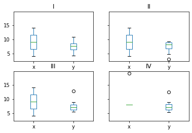

```python
quartets.groupby('quartet').boxplot(grid=False);
```

Seaborn's palettes

```python
sns.color_palette()
```

```python
sns.color_palette('pastel')
```

```python
palette = 'pastel'
```

**Seaborn's boxplots**

Similar boxplots with Matplotlib and Seaborn

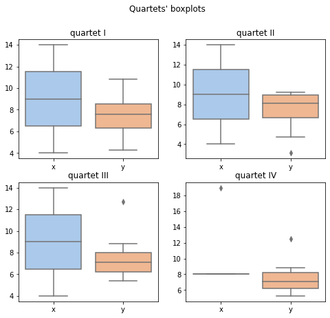

```python
fig, axes = plt.subplots(2, 2, figsize=(8,7))
axes = axes.flatten().tolist()
for quartet, g in quartets.groupby('quartet'):
    ax = axes.pop(0)
    sns.boxplot(data=g, ax=ax, palette=palette);
    ax.set_title(f'quartet {quartet}')
plt.suptitle("Quartets' boxplots");
```

Using seaborn boxplots to compare quartes's shared features

- [seaborn.boxplot()](https://seaborn.pydata.org/generated/seaborn.boxplot.html)
- [pandas.melt()](https://pandas.pydata.org/docs/reference/api/pandas.melt.html)

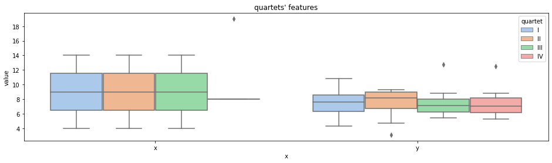

```python
fig, ax = plt.subplots(1, 1, figsize=(16,4))
sns.boxplot(x='x', y='value', hue='quartet',
            data=pd.melt(quartets, id_vars='quartet', var_name='x', value_name='value'),
            ax=ax, palette=palette)
ax.set_title("quartets' features");
```

The problem with the plot above is that we are forcing different features (like `x` and `y`) to share the same y-axis.

So, another way to acomplish the goal could be this one

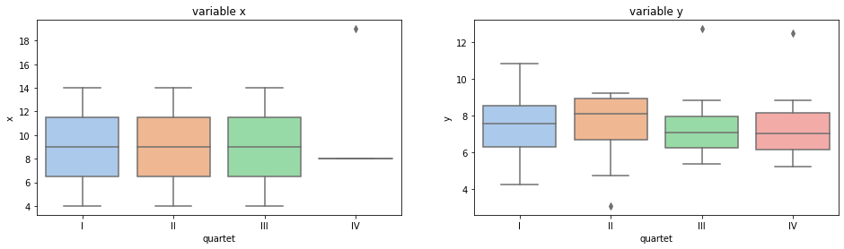

```python
fig, axes = plt.subplots(1, 2, figsize=(16,4))
for i, col in enumerate(['x', 'y']):
    sns.boxplot(x='quartet', y=col, data=quartets, ax=axes[i], palette=palette);
    axes[i].set_title(f'variable {col}')
```

### Histograms

Pandas let us easily plot the individual quartet's feature histogram in one line of code.

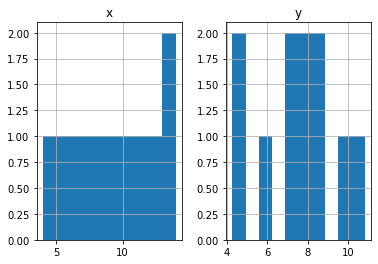

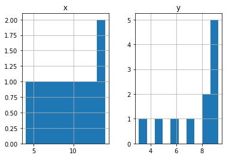

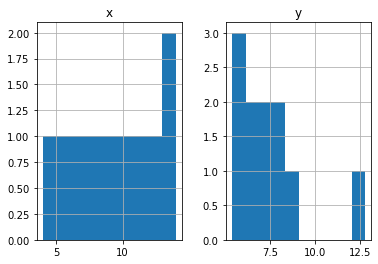

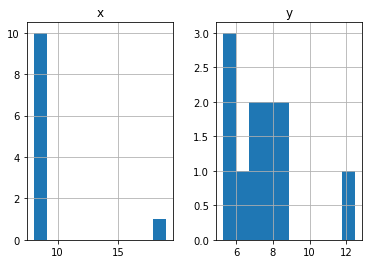

```python
quartets.groupby('quartet').hist();
```

The histograms allows us to start to see some differences

**Seaborn's histograms**

[seaborn.histplot()](https://seaborn.pydata.org/generated/seaborn.histplot.html)

We could do the same with seaborn with this code

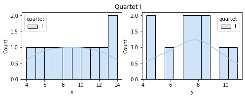

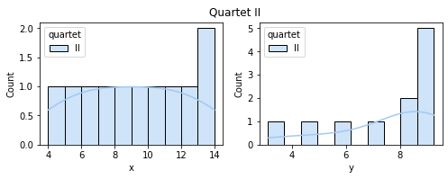

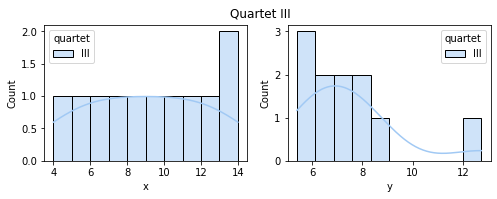

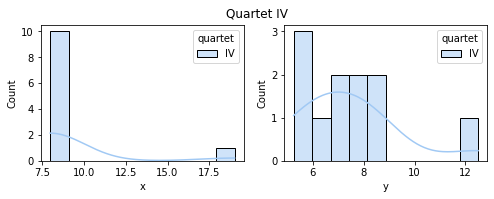

```python
for quartet, g in quartets.groupby('quartet'):
    fig, axes = plt.subplots(1 , 2, figsize=(8, 2.5))
    sns.histplot(data=g, x="x", hue='quartet', ax=axes[0], palette=palette, bins=10, kde=True);
    sns.histplot(data=g, x="y", hue='quartet', ax=axes[1], palette=palette, bins=10, kde=True);
    plt.suptitle(f'Quartet {quartet}')
```

We can plot all quartets's two features `x` and `y` in two different plots moving out the subplots creation

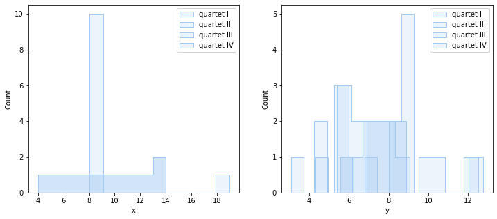

```python
# some elements are 'bars' (default but too noisy when plotting so many features), 'step', 'poly'
element = 'step'
fig, axes = plt.subplots(1 , 2, figsize=(12, 5))
legends = []
for quartet, g in quartets.groupby('quartet'):
    legends.append(f'quartet {quartet}')
    sns.histplot(data=g, x="x", hue='quartet', ax=axes[0], palette=palette, bins=10, kde=False, alpha=.2, element=element);
    sns.histplot(data=g, x="y", hue='quartet', ax=axes[1], palette=palette, bins=10, kde=False, alpha=.2, element=element);

axes[0].legend(legends)
axes[1].legend(legends);
```

### FacetGrid

This is a powerful tool that can be used in combination with ploting method from seaborn or even matplotlib to plot multiple subplots based on some conditional relationship.

[`seaborn.FacetGrid()`](https://seaborn.pydata.org/generated/seaborn.FacetGrid.html): Multi-plot grid for plotting conditional relationships.

**Grid of histograms**

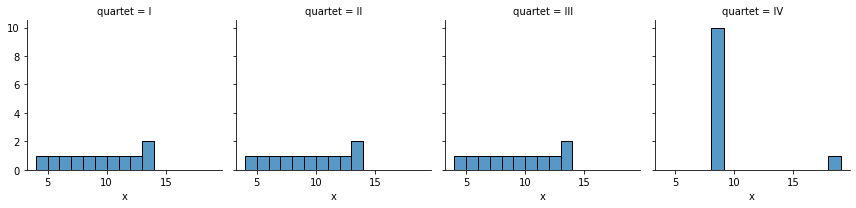

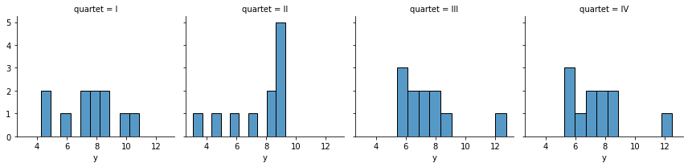

```python
for feature in ['x', 'y']:
    # create the grid with condition quartet
    g = sns.FacetGrid(quartets, col="quartet", palette=palette, col_wrap=4)
    # for every condition we are going to create a subplot for the grid for column "feature"
    g.map(sns.histplot, feature, bins=10);

# col_wrap define the number of columns. Change the value to 3 and 2 to understand visually its behaviour
```

We can create one FacetGrid for all. For that we need to convert the dataframe to access values based on conditions.

```python
melted = pd.melt(quartets, id_vars='quartet', var_name='x', value_name='value').rename(columns={'x':'variable'})
melted
```

|  | quartet | variable | value |
| --- | --- | --- | --- |
| 0 | I | x | 10.00 |
| 1 | I | x | 8.00 |
| 2 | I | x | 13.00 |
| 3 | I | x | 9.00 |
| 4 | I | x | 11.00 |
| ... | ... | ... | ... |
| 83 | IV | y | 5.25 |
| 84 | IV | y | 12.50 |
| 85 | IV | y | 5.56 |
| 86 | IV | y | 7.91 |
| 87 | IV | y | 6.89 |

88 rows × 3 columns

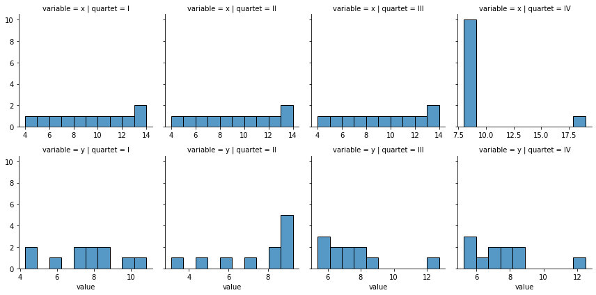

```python
# create the grid with quartets as columns and variable as rows
g = sns.FacetGrid(melted, row="variable", col='quartet', palette=palette, sharex=False)
g.map(sns.histplot, 'value', bins=10);
# we need set sharex to False to avoid distorting shapes between rows (you can try changing it to True)
```

### Scatter plots

Knowing that we have `x` and `y` features, we can think about using other kind of helpful plots. Why not a scatter plot?

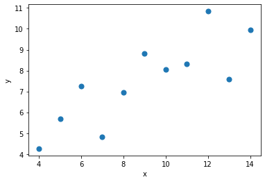

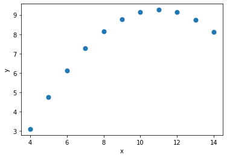

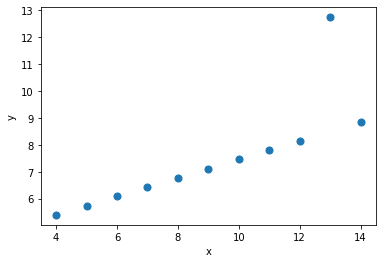

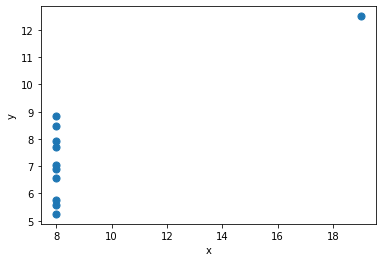

```python
quartets.groupby('quartet').plot.scatter(x='x', y='y', s=50);
```

**Scatter plots with seaborn**

We can combine matplotlib with seaborn to improve the aesthetic.

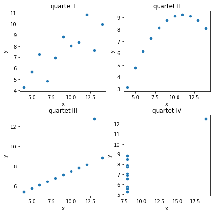

```python
fig, axes = plt.subplots(2,2,figsize=(7,7))
axes = axes.flatten().tolist()
for quartet, g in quartets.groupby('quartet'):
    ax = axes.pop(0)
    sns.scatterplot(data=g, x='x', y='y', ax=ax)
    ax.set_title(f'quartet {quartet}')
plt.subplots_adjust(hspace=0.3);
```

**Scatter plots with FacetGrid**

FacetGrid is great to avoid writting too many lines of matplotlib code. In this case we can force the grid to share x and y domain to simplify features domains comparison.

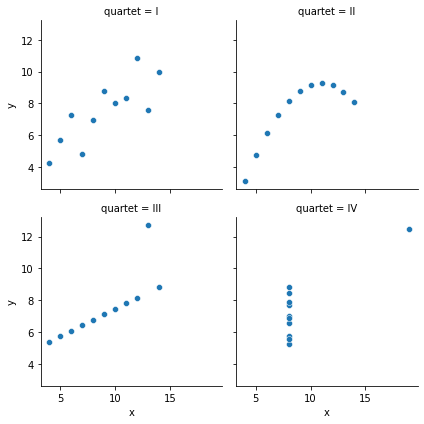

```python
g = sns.FacetGrid(quartets, col='quartet', palette=palette, col_wrap=2, sharex=True, sharey=True)
g.map(sns.scatterplot, 'x', 'y');
```

### Line plots

We could also use a lineplot but to do that we need to know that dots should be ordered in the x axis.

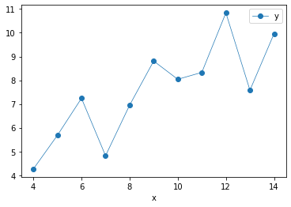

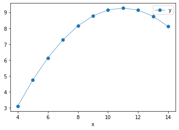

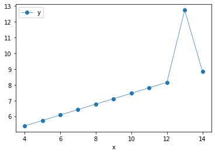

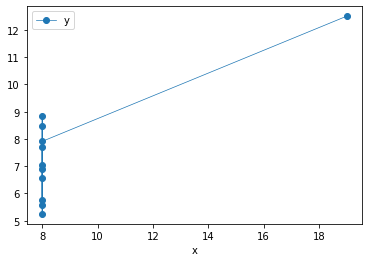

```python
quartets.sort_values(by='x').groupby('quartet').plot(x='x', y='y', marker='o', lw=.7);
```

### All in one

We also can use matplotlib to plot all groups in the same plot

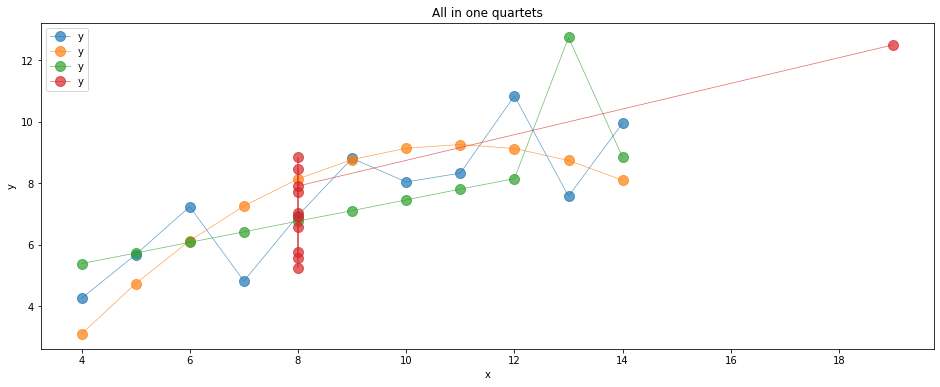

```python
# create one figure of 1 x 1 size.
fig, ax = plt.subplots(1,1,figsize=(16,6))
# plot all 4 quartets in the same ax
quartets.sort_values(by='x').groupby('quartet').plot(x='x', y='y', marker='o', ms=10, lw=.7, alpha=.7, ax=ax)
plt.ylabel('y')
plt.title('All in one quartets');
```

### Lineplots with seaborn

[Seaborn.lineplot()](https://seaborn.pydata.org/generated/seaborn.lineplot.html) simplifies the creation of the same plot.

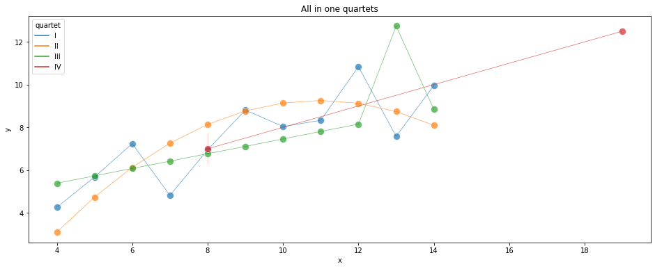

```python
fig, ax = plt.subplots(1,1,figsize=(16,6))
sns.lineplot(data=quartets, x='x', y='y', hue='quartet', marker='o', ms=10, lw=.7, alpha=.7, ax=ax)
plt.title('All in one quartets');
```

And we can plot all quartets together (removing the conditional `hue` for seaborn)

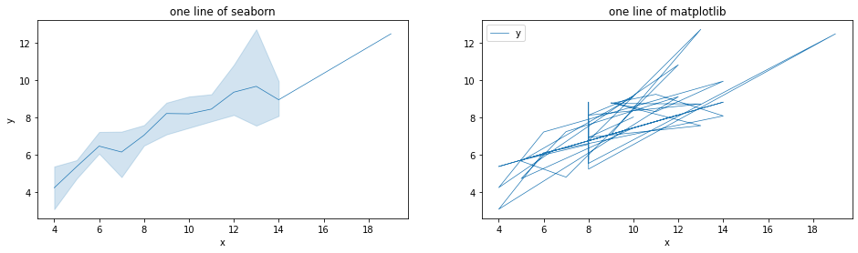

```python
fig, axes = plt.subplots(1,2,figsize=(16,4))
sns.lineplot(data=quartets, x='x', y='y', lw=.7, ax=axes[0])
axes[0].set_title('one line of seaborn')
quartets.plot(x='x', y='y', lw=.7, ax=axes[1])
axes[1].set_title('one line of matplotlib');
```

Seaborn is built on matplotlib, so using more lines of matplotlib should let you arrive to the same seaborn plot.

## Let´s use a different dataset

We will load an already known dataset.

Source: https://www.kaggle.com/spscientist/students-performance-in-exams  
Original source generator: http://roycekimmons.com/tools/generated_data/exams

If you go to the original source you will find this is a fictitious dataset created specifically for data science training purposes.

```python
df = pd.read_csv('StudentsPerformance.csv').rename(
        columns={
            'race/ethnicity': 'group',
            'parental level of education': 'parental',
            'test preparation course': 'course',
            'math score': 'math',
            'reading score': 'reading',
            'writing score': 'writing'
        }
    )
```

```python
df.info()
```

```
<class 'pandas.core.frame.DataFrame'>
RangeIndex: 1000 entries, 0 to 999
Data columns (total 8 columns):
 #   Column    Non-Null Count  Dtype
---  ------    --------------  -----
 0   gender    1000 non-null   object
 1   group     1000 non-null   object
 2   parental  1000 non-null   object
 3   lunch     1000 non-null   object
 4   course    1000 non-null   object
 5   math      1000 non-null   int64
 6   reading   1000 non-null   int64
 7   writing   1000 non-null   int64
dtypes: int64(3), object(5)
memory usage: 62.6+ KB
```

```python
df.head()
```

|  | gender | group | parental | lunch | course | math | reading | writing |
| --- | --- | --- | --- | --- | --- | --- | --- | --- |
| 0 | female | group B | bachelor's degree | standard | none | 72 | 72 | 74 |
| 1 | female | group C | some college | standard | completed | 69 | 90 | 88 |
| 2 | female | group B | master's degree | standard | none | 90 | 95 | 93 |
| 3 | male | group A | associate's degree | free/reduced | none | 47 | 57 | 44 |
| 4 | male | group C | some college | standard | none | 76 | 78 | 75 |

```python
df['group'].unique().tolist()
```

```
['group B', 'group C', 'group A', 'group D', 'group E']
```

### Let's simplify the dataframe

We can simplify the group values to the group letter

**Series.str**

[`Series.str`](https://pandas.pydata.org/docs/reference/api/pandas.Series.str.html): Vectorized string functions for Series and Index.

```python
df['group'] = df['group'].str[-1]
df['group'].unique().tolist()
```

```
['B', 'C', 'A', 'D', 'E']
```

```python
df.head()
```

|  | gender | group | parental | lunch | course | math | reading | writing |
| --- | --- | --- | --- | --- | --- | --- | --- | --- |
| 0 | female | B | bachelor's degree | standard | none | 72 | 72 | 74 |
| 1 | female | C | some college | standard | completed | 69 | 90 | 88 |
| 2 | female | B | master's degree | standard | none | 90 | 95 | 93 |
| 3 | male | A | associate's degree | free/reduced | none | 47 | 57 | 44 |
| 4 | male | C | some college | standard | none | 76 | 78 | 75 |

```python
df['course'].unique()
```

```
array(['none', 'completed'], dtype=object)
```

**Series.apply**

[`Series.apply`](https://pandas.pydata.org/docs/reference/api/pandas.Series.apply.html):Invoke function on values of Series.

```
Series.apply(func, convert_dtype=True, args=(), **kwargs)
```

```python
# we verify that we have never change this column values yet
if 'completed' in df['course'].unique().tolist():
    df['course'] = df['course'].apply(lambda x: 1 if x == 'completed' else 0)

# we can change the column values type to boolean
df['course'] = df['course'].astype(bool)
df['course'].unique()
```

```
array([False,  True])
```

```python
df.head()
```

|  | gender | group | parental | lunch | course | math | reading | writing |
| --- | --- | --- | --- | --- | --- | --- | --- | --- |
| 0 | female | B | bachelor's degree | standard | False | 72 | 72 | 74 |
| 1 | female | C | some college | standard | True | 69 | 90 | 88 |
| 2 | female | B | master's degree | standard | False | 90 | 95 | 93 |
| 3 | male | A | associate's degree | free/reduced | False | 47 | 57 | 44 |
| 4 | male | C | some college | standard | False | 76 | 78 | 75 |

## Missing values

```python
df.isna().sum()
```

```
gender      0
group       0
parental    0
lunch       0
course      0
math        0
reading     0
writing     0
dtype: int64
```

None of the column series present missing values

**Some questions:**

- Does gender affect math scores?
- Does math scores affect gender?
- Does reading and writing scores affect math scores?
- Do math scores affect reading and writing scores?
- Does a group perform better at math than the rest?
- Does parental level education affect math scores?

```python
df[['reading','math']].sample(5)
```

|  | reading | math |
| --- | --- | --- |
| 340 | 61 | 58 |
| 370 | 77 | 84 |
| 186 | 76 | 80 |
| 687 | 78 | 77 |
| 499 | 71 | 76 |

```python
df[['reading','math']].describe()
```

|  | reading | math |
| --- | --- | --- |
| count | 1000.000000 | 1000.00000 |
| mean | 69.169000 | 66.08900 |
| std | 14.600192 | 15.16308 |
| min | 17.000000 | 0.00000 |
| 25% | 59.000000 | 57.00000 |
| 50% | 70.000000 | 66.00000 |
| 75% | 79.000000 | 77.00000 |
| max | 100.000000 | 100.00000 |

It's not common at all to see a zero on scores. Here we see a 0 found at math

```python
df[df['math'] == 0]
```

|  | gender | group | parental | lunch | course | math | reading | writing |
| --- | --- | --- | --- | --- | --- | --- | --- | --- |
| 59 | female | C | some high school | free/reduced | False | 0 | 17 | 10 |

Does this sample look possible? Why?